# Elegant Color in R Advanced Graphics

Qianjiang Hu

2021-02-13

## **Overview**

R is a programming language and free software environment for statistical computing and graphics supported by the R Foundation for Statistical Computing. It is also extremely flexible with high perfermance in creating data visualisations. Above all, the color scheme is one of the key elements of a data visualization. This post will present colors in basic R and ggplot.

## **Colors in Basic R**

### Built-in color names

R has 657 built in color names. That can be listed by `colors()`.

```r
colors()[c(1:10)]
```

```
##  [1] "white"         "aliceblue"     "antiquewhite"  "antiquewhite1"
##  [5] "antiquewhite2" "antiquewhite3" "antiquewhite4" "aquamarine"
##  [9] "aquamarine1"   "aquamarine2"
```

Instead of using a color name, color can also be called by Hex code. Hex code define a color as a 6 hexadecimal digit number of the form `#RRGGBB`, in which `RR` is for red, `GG` for Green and `BB` for blue. Two additional characters (with the same scale) can be added to the end to describe transparency (#rrggbbaa). The function `seecol()` in `unikn` package offers a way to view color palettes. You can search a perfect color by an online tool `color picker`. https://htmlcolorcodes.com/

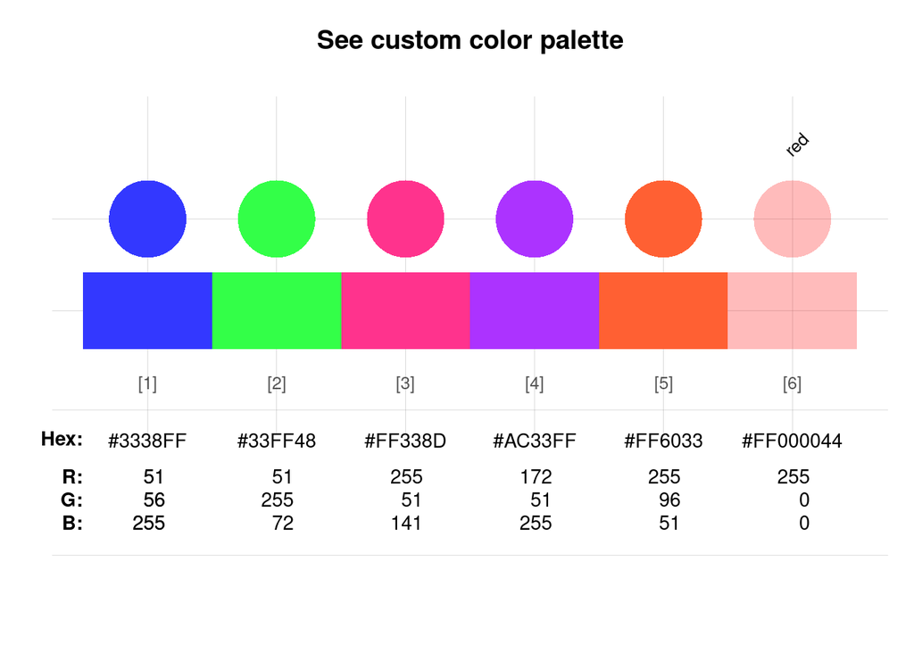

```r
library('unikn')             # loads the package
seecol(c('#3338FF','#33FF48','#FF338D','#AC33FF','#FF6033',"#FF000044"))
```

### RGB color via `rgb()` - Combination of numbers for red, green and blue component - Default range between 0 and 1 - maxColorValue = 255 adjusts the range to the standard notation - alpha produces transparent colors

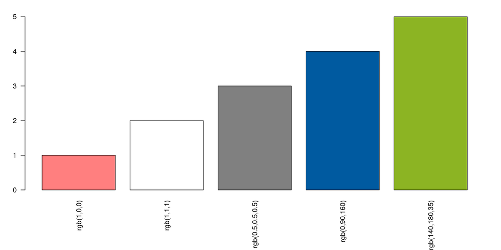

```r
par(mar = c(7,3,2,2))
barplot(1:5, col =
          c(rgb(red = 1, green = 0, blue = 0, alpha = 0.5),  # alpha produce the transparent color
            rgb(red = 1, green = 1, blue = 1),
            rgb(red = 0.5, green = 0.5, blue = 0.5),
            rgb(0 , 90, 160, maxColorValue = 255),
            rgb(140, 180, 35, maxColorValue = 255)),
        names.arg =
          c('rgb(1,0,0)','rgb(1,1,1)','rgb(0.5,0.5,0.5)','rgb(0,90,160)','rgb(140,180,35)'),
        las = 2)
```

R can translate colors to rgb by `col2rgb()` (It gives interaction for matching colors in other programs)

```r
col2rgb(c('#FF0000', 'blue'))
```

```
##       [,1] [,2]
## red    255    0
## green    0    0
## blue     0  255
```

### HCL color

Package `colorspace` support the mapping HCL(Hue-Chroma-Luminance) color system, a perceptually-based and device-independent color model. - `qualitative_hcl()` create colors with same perceptual weight - `sequential_hcl()` create colors of decreasing luminance - `diverging_hcl()` create transmissions between two colors - `palette()` presents pre-specified patterns - `n` sets number of steps - `h`, `c`, `l`: parameters of color coding alternative - use `hcl_palettes(plot = TRUE)` to check all examples - `power` determines the speed of change: `power = 1`: linear, `power = 2`: quadratic

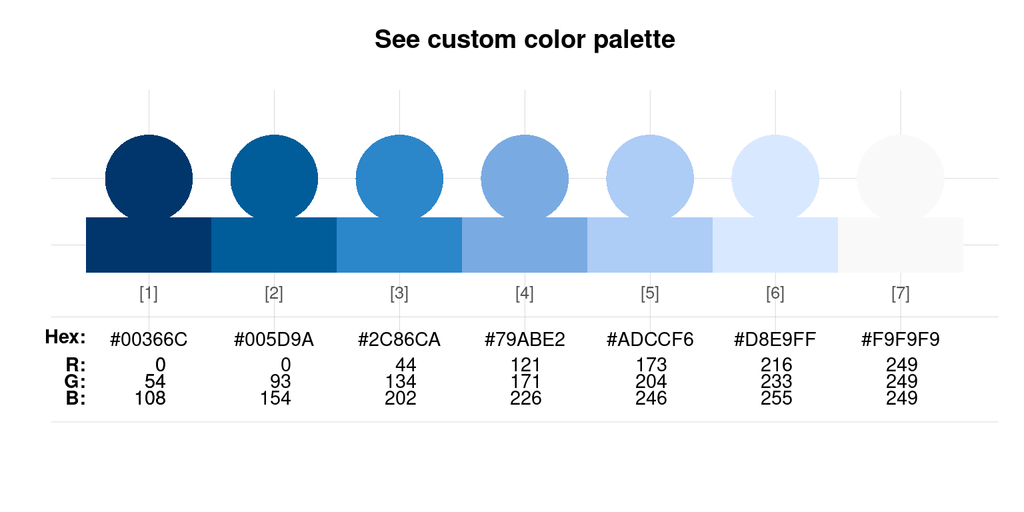

```r
library(colorspace)
col1 <- sequential_hcl(n = 7, palette = "Blues 3")
col2 <- diverging_hcl(n = 7, palette = "Blue-Red2")
col3 <- qualitative_hcl(7, palette = "Dark 3")
seecol(col1)
```

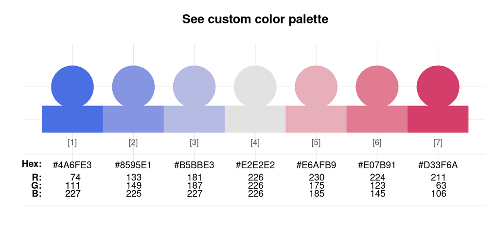

```r
seecol(col2)
```

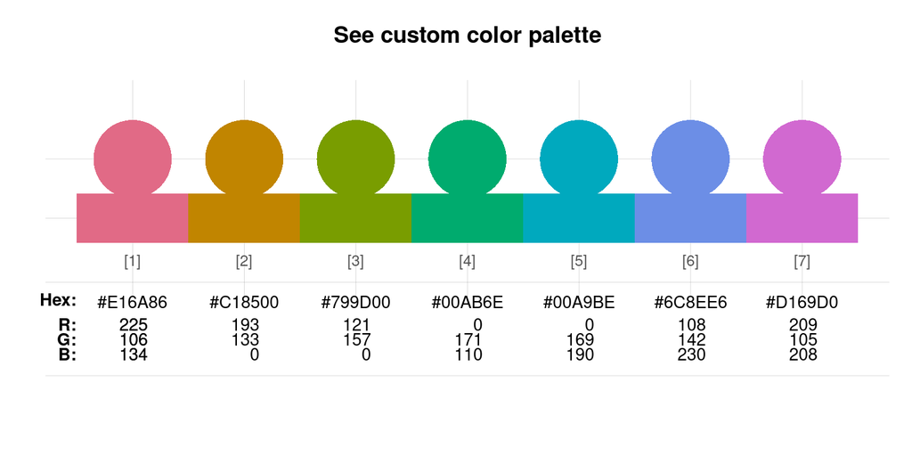

```r
seecol(col3)
```

Customized color verctors are also available with colorspaceby vector.

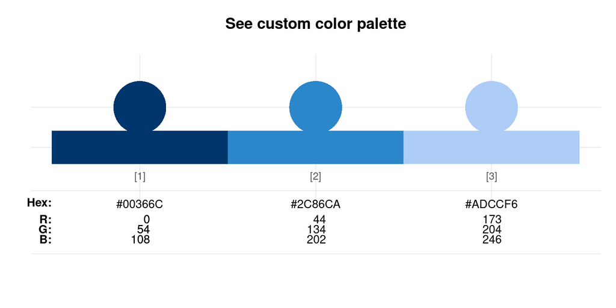

```r
col4 <- sequential_hcl(n = 7, palette = "Blues 3")[c(1,3,5)]
seecol(col4)
```

There is also an interactive tool that can be used to obtain a customized palette. To start the tool: `colp <- choose_palette()`

### ColorRampPalette

Another powerful color schemes is ColorRampalette with both `colorRamp()` and `colorRampPalette()` function. With two input colors, both functions can generate an entire spectrum of colors by mixing together different amounts of two colors.

```r
cr <- colorRamp(c("red", "blue"))
cr(0)
```

```
##      [,1] [,2] [,3]
## [1,]  255    0    0
```

Any value between 0 and 1, even a sequence of numbers, can be passed to colorRmp.

```r
cr <- colorRamp(c("red", "blue"))
cr(seq(0,1,len = 8))
```

```
##           [,1] [,2]      [,3]
## [1,] 255.00000    0   0.00000
## [2,] 218.57143    0  36.42857
## [3,] 182.14286    0  72.85714
## [4,] 145.71429    0 109.28571
## [5,] 109.28571    0 145.71429
## [6,]  72.85714    0 182.14286
## [7,]  36.42857    0 218.57143
## [8,]   0.00000    0 255.00000
```

The `colorRampPalette()` shares the similar funtion with `colorRamp()`, however the function that it returns gives you a fixed number of colors that interpolate the palette.

```r
cr <- colorRampPalette(c("red", "blue"))
cr(1)
```

```
## [1] "#FF0000"
```

```r
cr(3)
```

```
## [1] "#FF0000" "#7F007F" "#0000FF"
```

`colorRampPalette(colors = c(.,.), alpha)(n = ...)` build sequential and divering color-schemes based on rgb coding. Same color for start and end with different transparency produce sequential scheme. Two different colors for start and end produces diverging scheme.

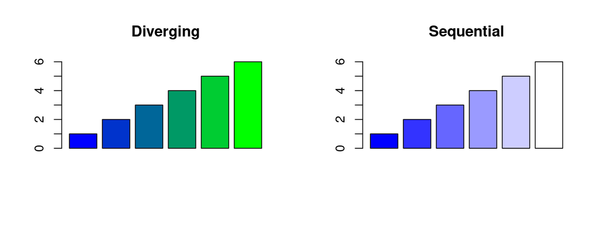

```r
par(mfrow = c(1,2))
barplot(1:6, main = "Diverging",
        col = colorRampPalette(colors = c(rgb(0, 0, 1), rgb(0, 1, 0)))(n = 6))
barplot(1:6, main = "Sequential",
        col = colorRampPalette(colors = c(rgb(0, 0, 1, alpha = 1),
                                          rgb(0, 0, 1, alpha = 0)),
                               alpha = TRUE)(n = 6))
```

In addition, `colorRamp()` generates contrast color palette, while `colorRampPalette()` generates a gradient color pallette.

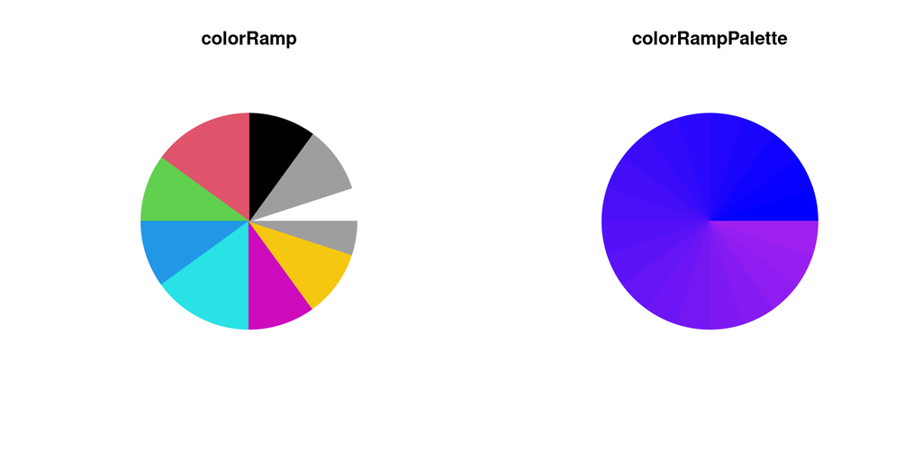

```r
par(mfrow = c(1, 2))
pc1 <- colorRamp(c("blue", "purple"))
pc2 <- colorRampPalette(c("blue", "purple"))
pie(rep(1, 20), labels = "", col = pc1(seq(0, 1, len = 20)),
    border = pc1(seq(0, 1, len = 20)), main = "colorRamp")
pie(rep(1, 20), labels = "", col = pc2(20), border = pc2(20),
    main = "colorRampPalette")
```

```r
dev.off()
```

### RColorBrewer

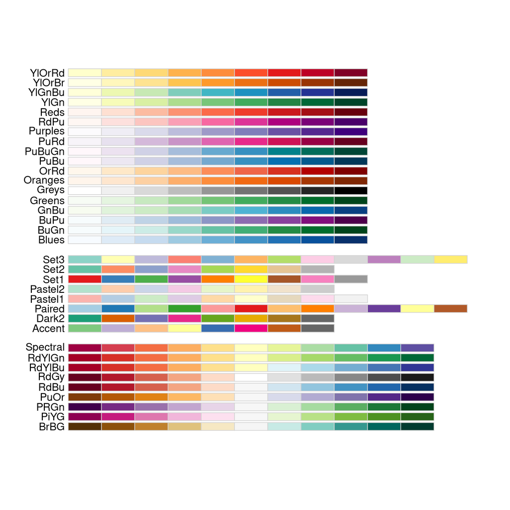

```r
library(RColorBrewer)
display.brewer.all()
```

```r
library(RColorBrewer)
cols <- brewer.pal(3, "BuGn")
cols
```

```
## [1] "#E5F5F9" "#99D8C9" "#2CA25F"
```

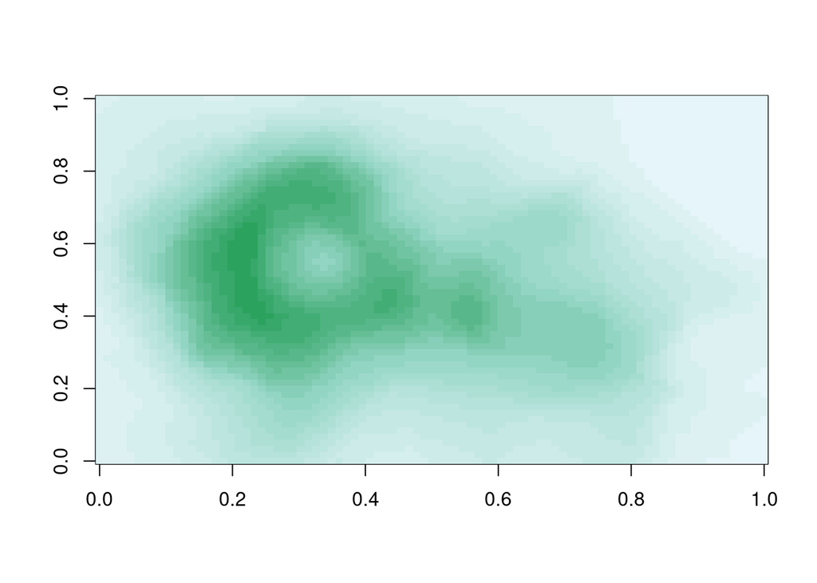

```r
pal <- colorRampPalette(cols)
image(volcano, col = pal(20))
```

### Other Palettes

There are also some recommended palettes built-in R: `cm.colors()`, `topo.colors()`, `terrain.colors()`, `heat.colors()`, `rainbow()`, `gray.colors()`

## **Colors in `gglot2`**

Most of the color palettes including `R names` and `Hex code` are still available in `ggplot2`. Customized color vectors are also work in `ggplot2`. Additionally, ggplot2 is compatible with some other color palettes.

### fill vs. col

`ggplot2` allows to customize the colors thanks to its `fill` and `color` arguments. In general, `fill` give the color with which a geom is filled, whereas `color` define the colors with which a geom is outlined.

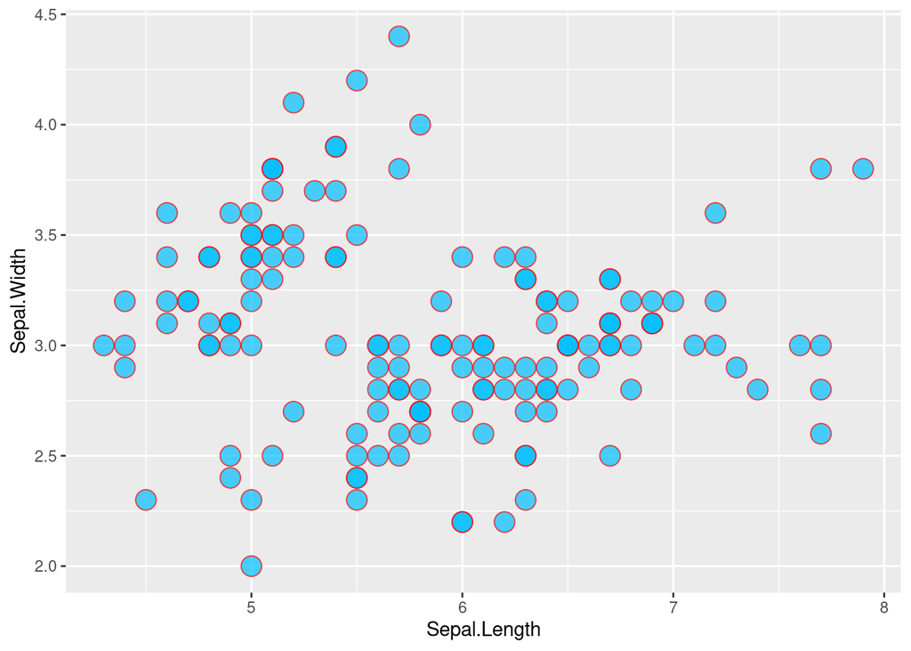

```r
library(ggplot2)
ggplot(data = iris, mapping = aes(x = Sepal.Length, y =Sepal.Width)) +
  geom_point(col = 'red', fill = 'deepskyblue', shape = 21, size = 5, alpha = 0.7)
```

### Default colors in ggplot2

Default colors are defined by `hcl()` with the discipline `hcl(h = (seq(15, 375-360/n, length = n)), c = 100, l = 65)`. Therefore, all colors have the same luminance and chroma. Additionally, `show_col()` in packages `scales` offer the other way to check colors.

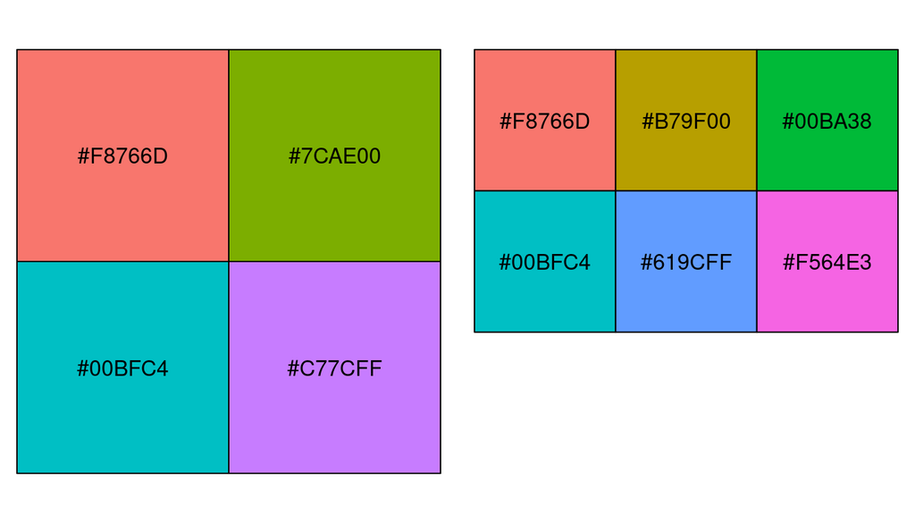

```r
# Visualize the colors depending on the number of categories by
par(mfrow = c(1,2))
library(scales)
show_col(hue_pal() (4))    #please note the space between `hue_pal()` and `n`
show_col(hue_pal() (6))
```

### Set a ggplot color by groups

(i.e. by a factor variable) This is done by mapping a grouping variable (aesthetic) to the color or to the fill arguments.

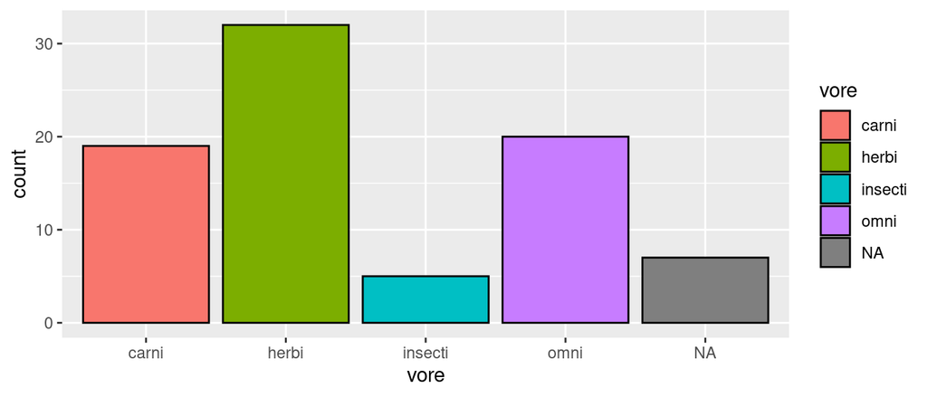

```r
library('ggplot2')
sleep <- as.data.frame(msleep)
Plot1 <- ggplot(data = sleep, aes(x = vore)) +
  geom_bar(aes(fill = vore), col = "black") # fill define the aesthetic mapping in which variable `vore` will be filed with color
Plot1
```

### Discrete colors

#### *`scale_fill_hue`*

Change colors in ggplot2 by `scale_fill_hue` and `scale_color_hue` Use grey scale via `scale_fill_grey()` `na.value`: Change color of category `NA`

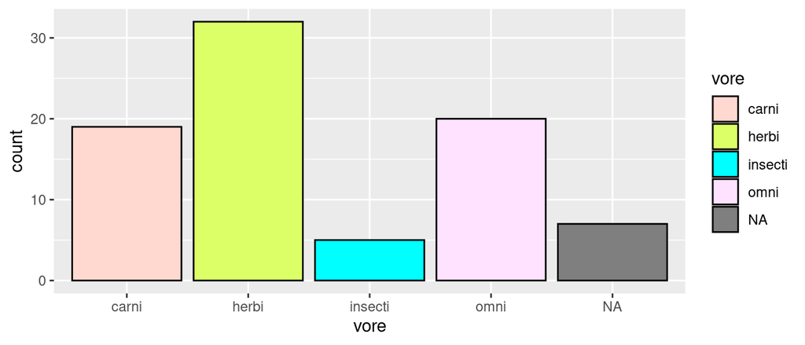

```r
par(mfrow = c(1,2))
Plot1 +
  scale_fill_hue(l = 100)
```

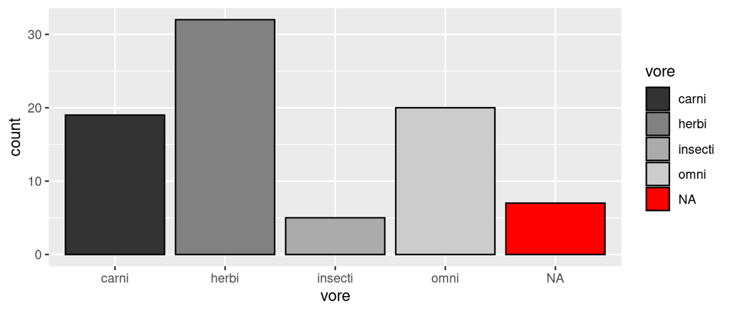

```r
Plot1 +
  scale_fill_grey()
```

#### *`cale_fill_brewer()`*

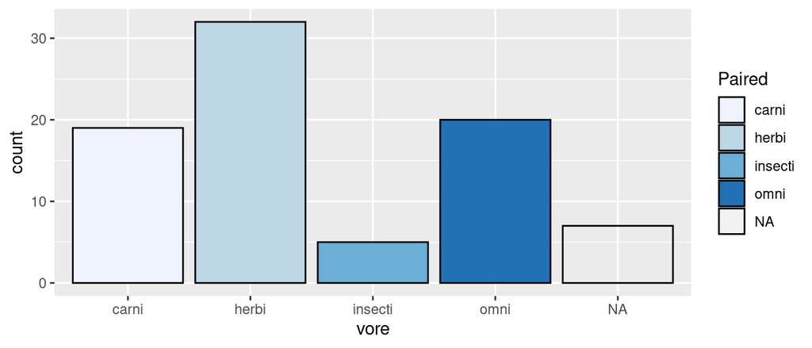

```r
Plot1 +
  scale_fill_brewer('Paired')
```

Check all colors in `RcolorBrewer` via `RColorBrewer::display.brewer.all(n)`

#### *`scale_fill_manual()`*

Define discrete colors manually in ggplot2 via `scale_fill_manual()` and `scale_color_manual()` Firstly, it is necesary to build either a vector of colors or a vector of categories and colors.

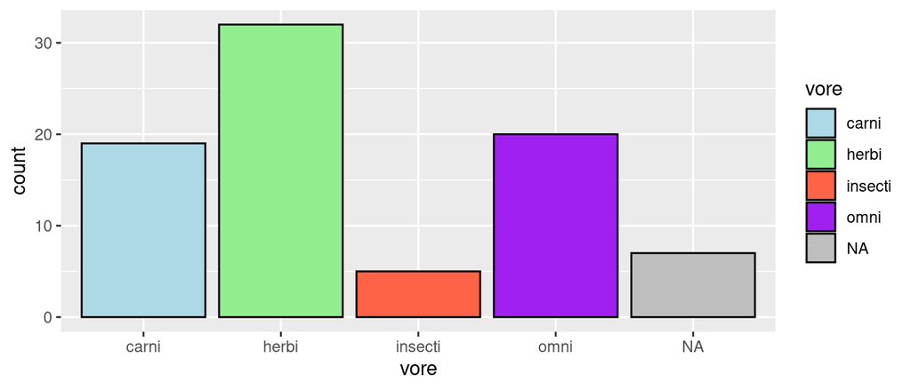

```r
newcol <- c("carni" = "lightblue", "herbi" = "lightgreen", "insecti" = "tomato", "omni" = "purple")
Plot1 +
  scale_fill_manual(values = newcol, na.value = "grey")
```

Similar with `scale_fill_manual()`, `scale_shape_manual()` giva a way to self-define shapes of categories via a shape vector.

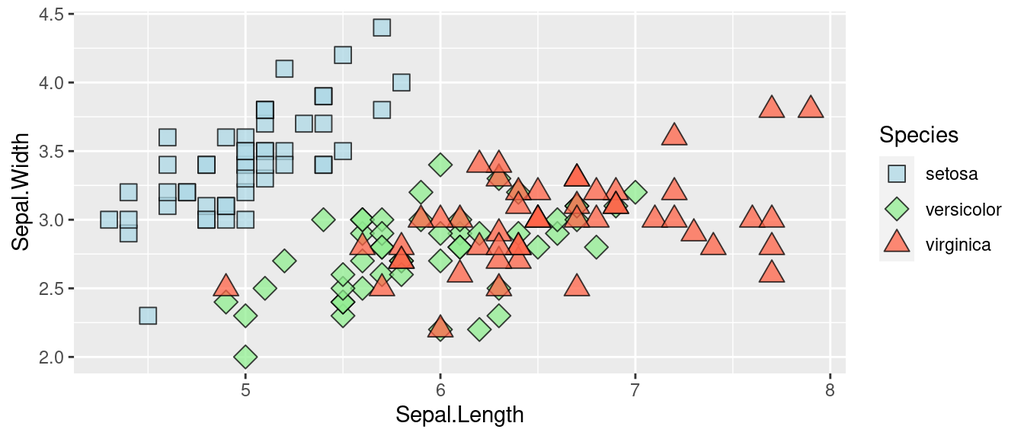

```r
mcol <- c('setosa' = 'lightblue',  'versicolor'= 'lightgreen', 'virginica' = 'tomato')
mshape <- c('setosa' = 22,  'versicolor'= 23, 'virginica' = 24)
ggplot(data = iris,  mapping = aes(x = Sepal.Length, y = Sepal.Width)) +
  geom_point(mapping = aes(fill = Species, shape = Species), size =  4, alpha = 0.75)+
  scale_fill_manual(values = mcol, na.value = 'grey')+
  scale_shape_manual(values = mshape, na.value = 9)
```

### Gradient Colors

When a categrory variable is used to asethetic, discrtete colors are required. Whereas, when a continuouse variable is used for scaling, then a gradient color is necessary.

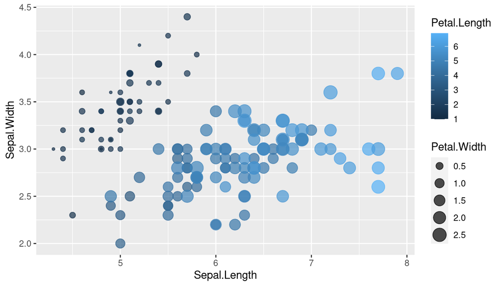

```r
Plot2 <- ggplot(data = iris,  mapping = aes(x = Sepal.Length, y = Sepal.Width)) +
  geom_point(mapping = aes(color = Petal.Length, size = Petal.Width),  alpha = 0.7)
Plot2
```

- `scale_fill_gradient()` creates a two color gradient (low-high)
- `scale_fill_gradient2()` creates a three color gradient (low-mid-high, midpoint)

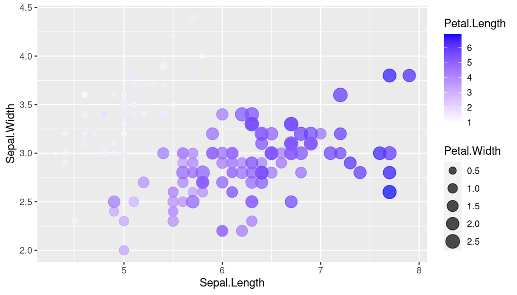

```r
par(mfrow = c(1,2))
Plot2 + scale_color_gradient(low = 'white', high = 'blue')
```

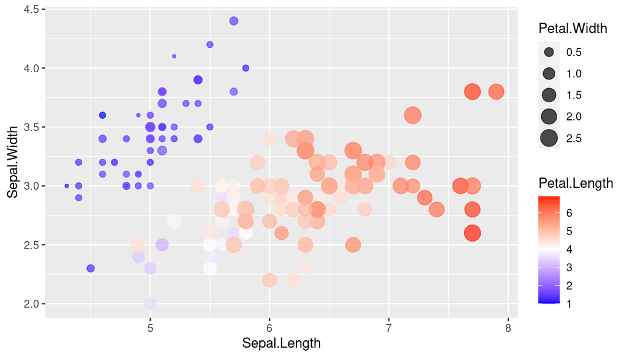

```r
Plot2 + scale_color_gradient2(low = 'blue', mid = 'white',high = 'red', midpoint = 4)
```

#### *limits of continuous colors*

The upper and lower end of the gradient color scheme can be changed via the argument `limits` • scale_fill_gradient() changes also the color pattern • scale_fill_continuous() changes only the limits

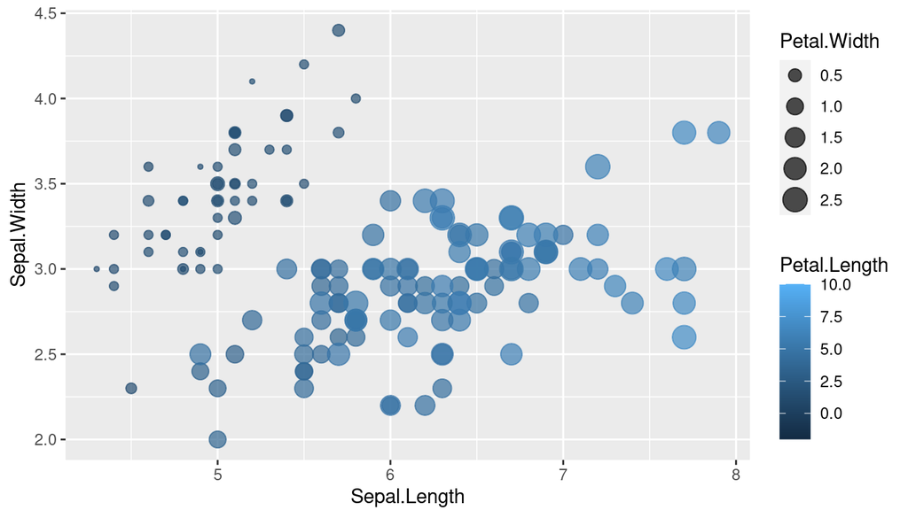

```r
par(mfrow = c(1,2))
Plot2 + scale_color_continuous(limits= c(-2,10))
```

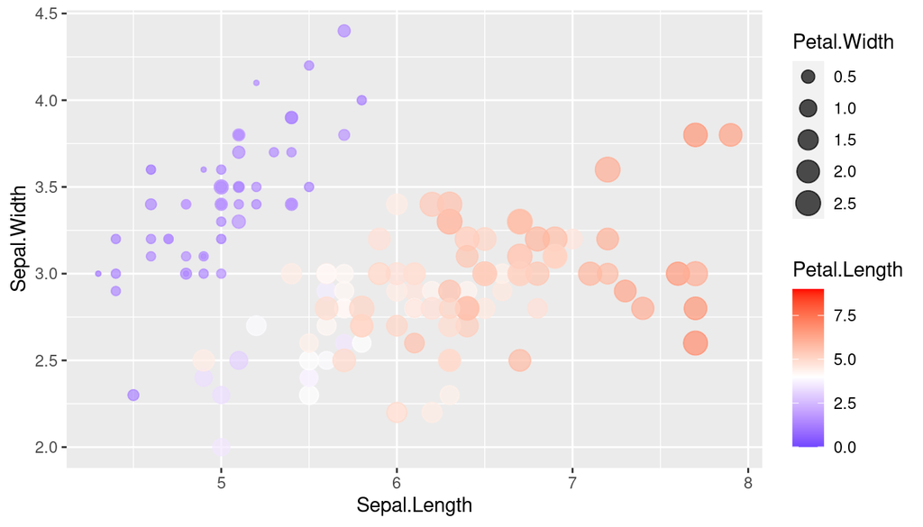

```r
Plot2 + scale_color_gradient2(low = 'blue', mid = 'white',high = 'red', midpoint = 4, limits = c(0,9))
```

### Global default of colors

`options()` Allow the user to set and examine a variety of global options which affect the way in which R computes and displays its results.

Global adjustment of color pattern via options(), e.g. * options(ggplot2.continuous.colour = brewer.pal(8, “Dark2”)) * options(ggplot2.continuous.fill = brewer.pal(8, “Dark2”)) * options(ggplot2.discrete.colour = brewer.pal(8, “Dark2”)) * options(ggplot2.discrete.fill = brewer.pal(8, “Dark2”))

*NOTE* Before changing colors globally, save the default via:

```r
opts <- options()
```

## **Others**

### Color info

To extract colors (other info as well) of a ggpplot use `ggplot_build()`

```r
ggplot_build(Plot1)$data[[1]]
```

```
##      fill  y count prop x flipped_aes PANEL group ymin ymax xmin xmax colour
## 1 #F8766D 19    19    1 1       FALSE     1     1    0   19 0.55 1.45  black
## 2 #7CAE00 32    32    1 2       FALSE     1     2    0   32 1.55 2.45  black
## 3 #00BFC4  5     5    1 3       FALSE     1     3    0    5 2.55 3.45  black
## 4 #C77CFF 20    20    1 4       FALSE     1     4    0   20 3.55 4.45  black
## 5  grey50  7     7    1 5       FALSE     1     5    0    7 4.55 5.45  black
##   size linetype alpha
## 1  0.5        1    NA
## 2  0.5        1    NA
## 3  0.5        1    NA
## 4  0.5        1    NA
## 5  0.5        1    NA
```

## **References:**

1. https://htmlcolorcodes.com/
2. https://www.r-graph-gallery.com/ggplot2-color.html
3. https://bookdown.org/rdpeng/exdata/plotting-and-color-in-r.html
4. https://www.nceas.ucsb.edu/sites/default/files/2020-04/colorPaletteCheatsheet.pdf